# Statistical Study on Nutri-Score for Pizza, Pies, and Quiches Products in the United States

## Introduction

Le Nutri-Score serves as a simplified nutritional labeling system that categorizes foods based on their nutritional quality, assigning them a letter grade from A for the healthiest products to E for the least healthy ones, providing consumers with an overview of the overall nutritional value. Designed to guide consumers in their food choices, this system aims to promote healthier eating habits.

Our study focuses on pizzas, pies, and quiches in the United States, encompassing a dataset of 3133 observations. The objective of our research is to provide consumers with reliable and relevant information on the Nutri-Score to enhance their understanding of nutritional labeling. To achieve this goal, we will conduct a comprehensive analysis through the utilization of graphs, tables, and statistics.

## Graphs and Statistics

### Distribution of Nutri-Score Grades

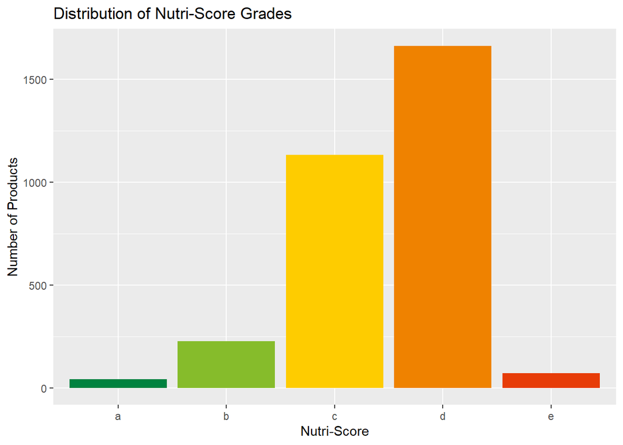

We observe that the majority of products in the pizza/pie/quiche category are classified as C or D on the Nutri-Score, while products classified as A or E are very rare.

### Impact of Lipids on Nutri-Score

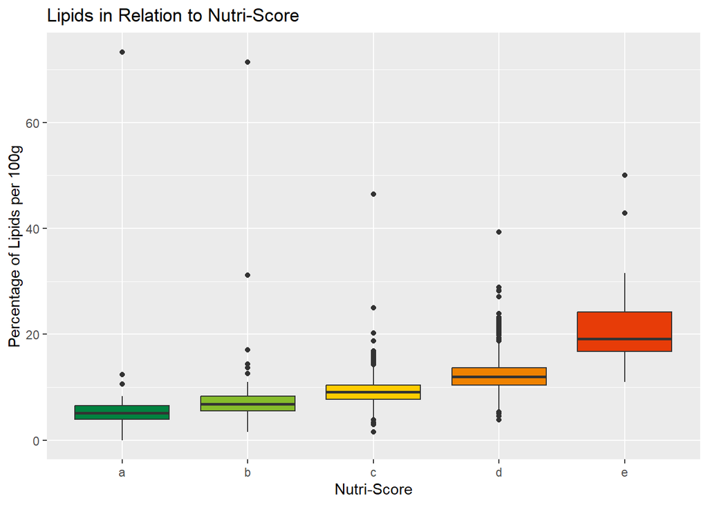

Products with more than 40% lipids include pecans, pepperoni packets, or almonds for apple pies, and 0% lipids are not plausible.

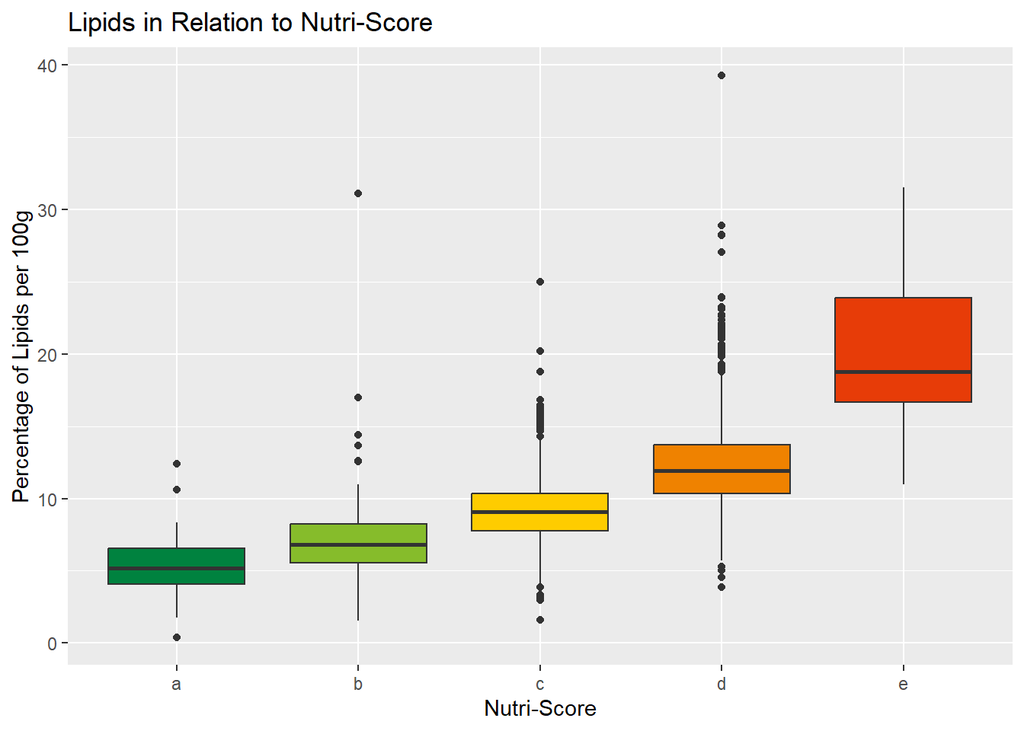

After filtering lipids, we notice that the higher the lipid content, the lower the Nutri-Score.

### Impact of Carbohydrates on Nutri-Score

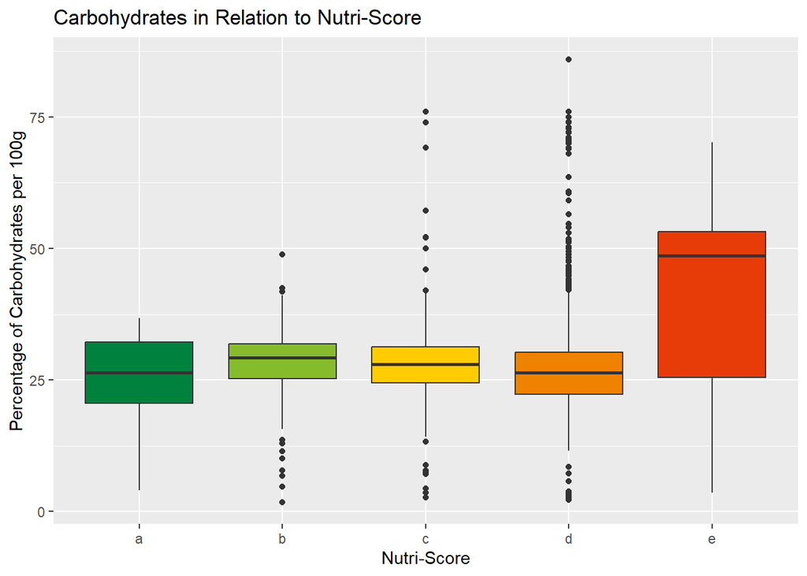

The data point with over 79g of carbohydrates represents a lemon meringue pie preparation kit, which does not belong to our product category.

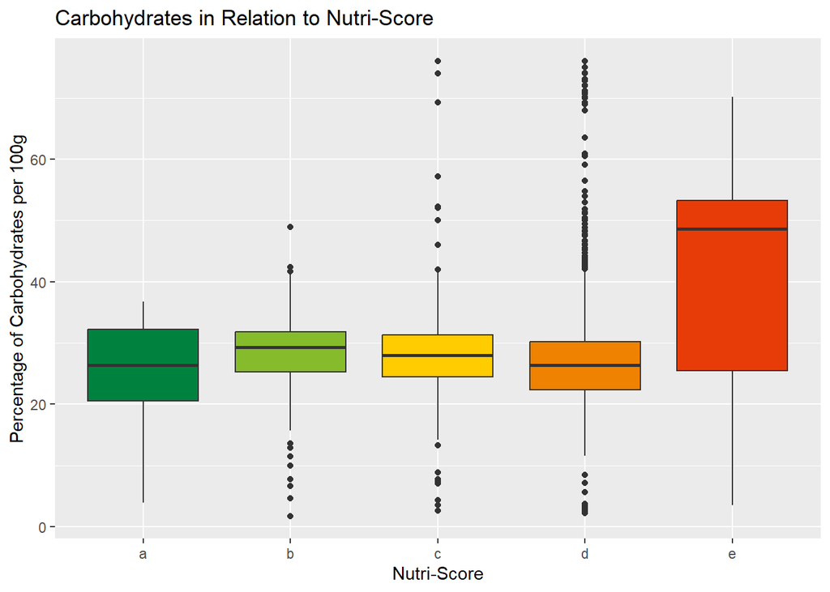

We observe that sugar has little impact on the Nutri-Score for this product category. However, the E category shows a wide variability of values with many sweet products. It is likely that sweet pies are mostly classified as E. Additionally, there is a clustering of very sweet products in D, corresponding to sweet pies.

### Impact of Proteins on Nutri-Score

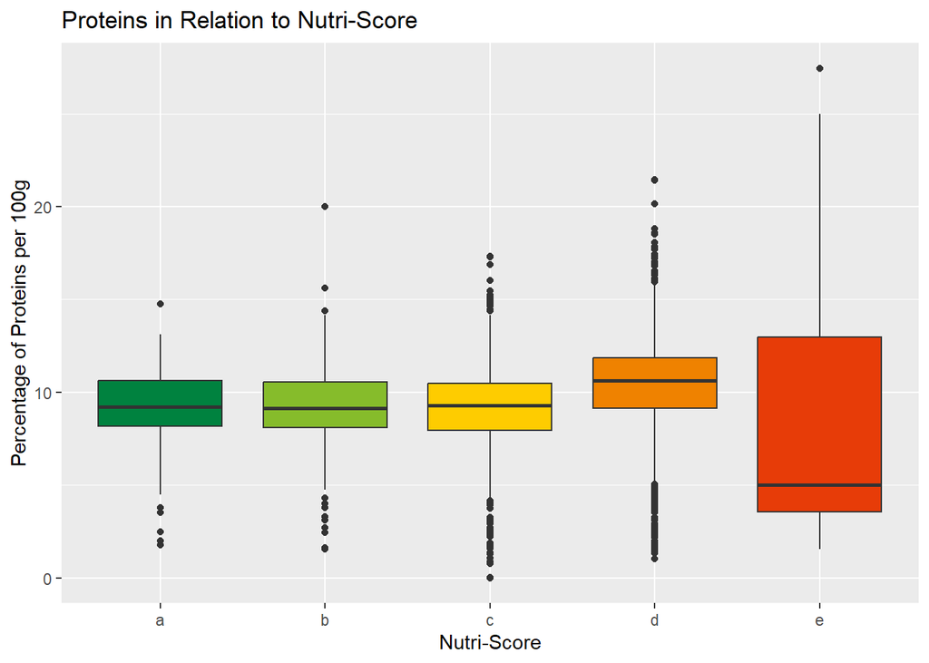

A product in our category with 0g of proteins is not plausible. Furthermore, the value of over 25g of proteins is incorrect, as the pizza packaging indicates 14g of proteins per 119g.

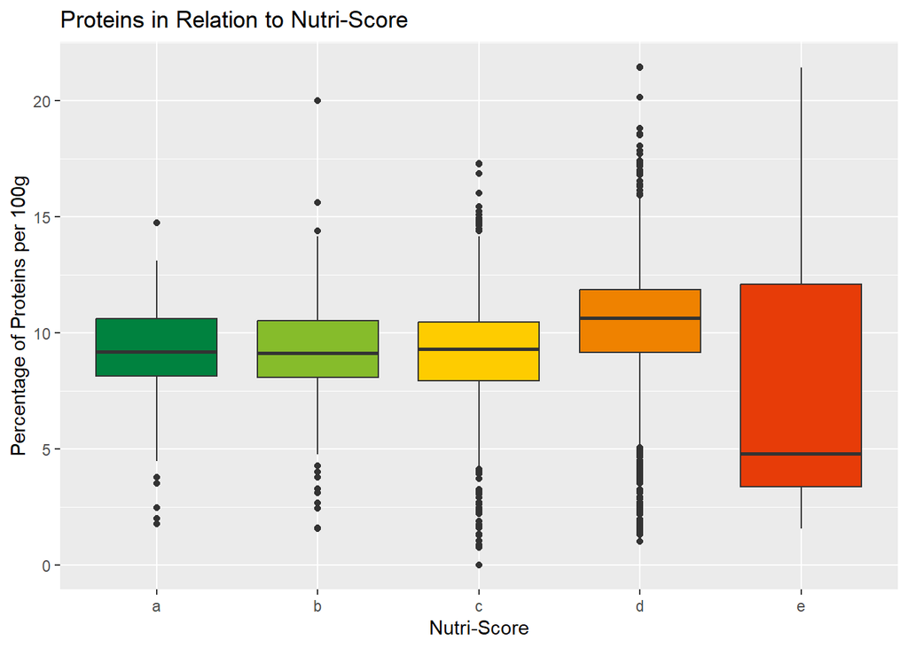

Similar to the above, sweet pies are likely to contain fewer proteins.

### Impact of Salt on Nutri-Score

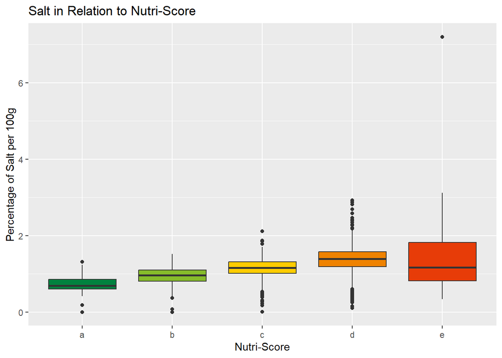

The data point with over 7g of salt is an error, as the sodium quantity was used instead of salt. Additionally, values at 0g are also errors or do not correspond to the category.

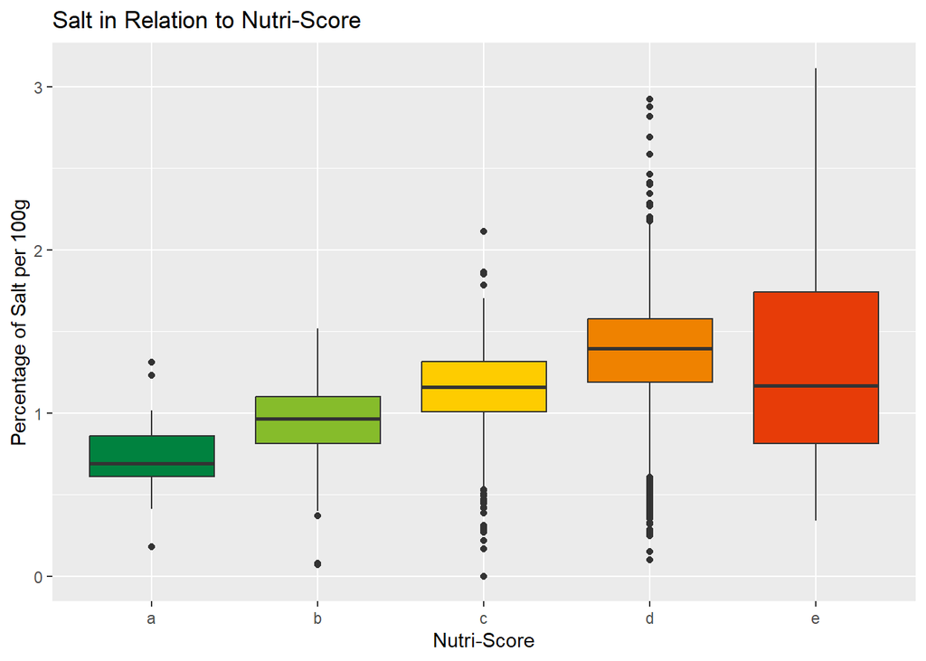

We observe that the higher the salt content, the lower the Nutri-Score.

### Impact of Energy on Nutri-Score

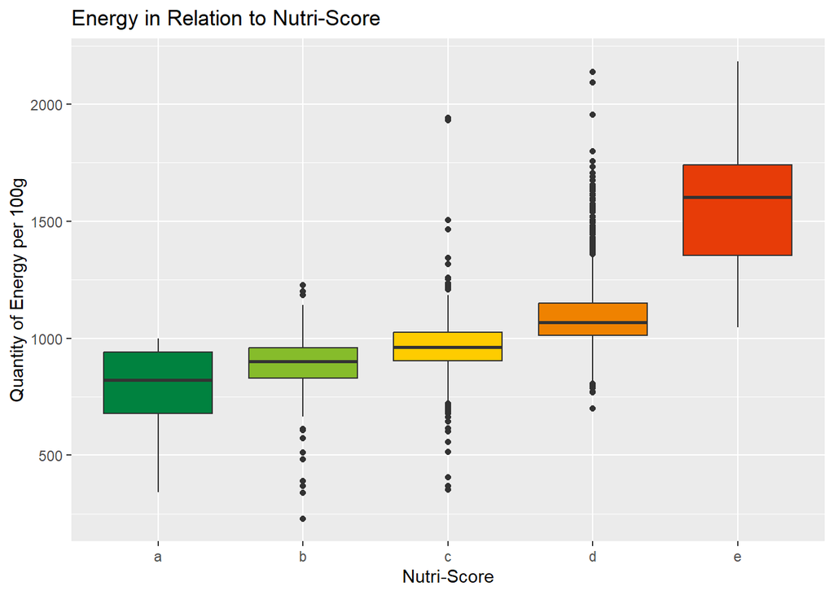

On this graph, we notice that products with lower Nutri-Scores contain more energy. Moreover, sweet pies are significantly higher in energy compared to other products.

### Impact of Organic, Vegan, and Palm Oil-Free Attributes on Nutri-Score

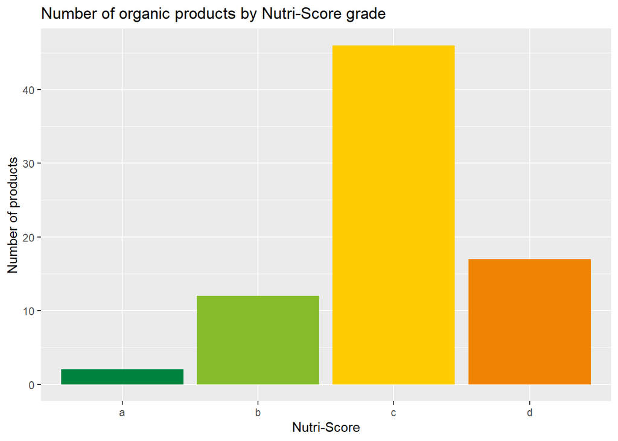

We observe that no organic product is classified as Nutri-Score E, and they generally receive better scores.

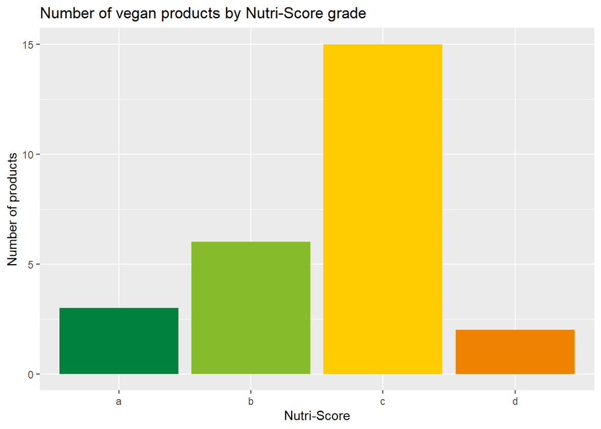

The same observation applies to vegan products.

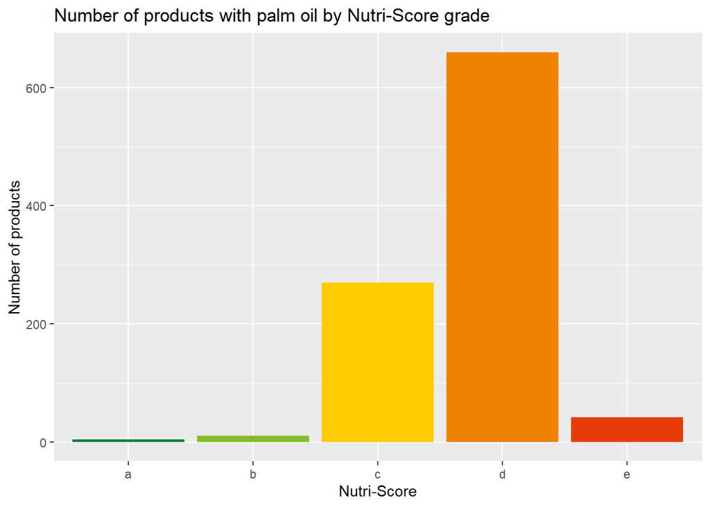

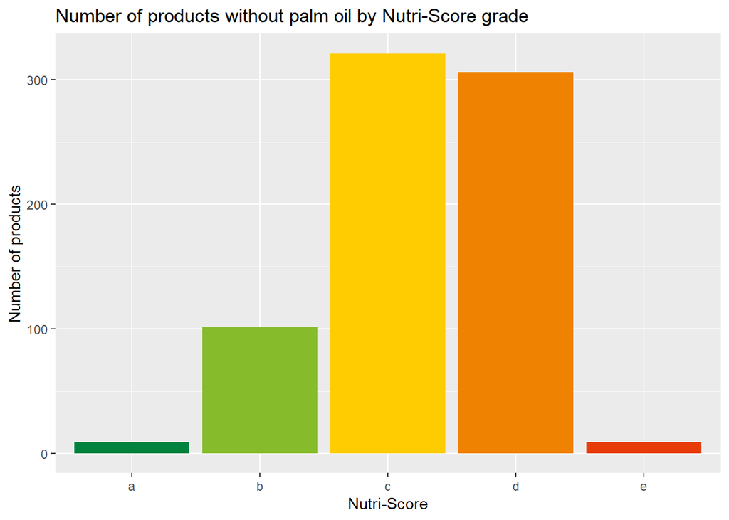

Finally, products without palm oil are generally better rated than those with palm oil.

## Conclusion

Furthermore, it’s worth noting that vegan, organic, and palm oil-free products tend to receive better evaluations for health, boasting a more favorable nutritional composition. However, it’s essential to recognize that the Nutri-Score isn’t tailored to specific product categories. Certain products, inherently designed to be sweet (such as pastries like pies), will inevitably receive lower Nutri-Scores. Therefore, while these labels offer valuable insights, they should be interpreted contextually, considering the nature of the products being assessed.